# Cars93

# 1. Загрузка данных

```r
df <- read_xls("./93CARS.STD/93CARS_shortname.xls", na = "_")
colnames(df)[19] <- "LENGTH"
df <-
  df |>
  filter(!(TYPE %in% c("VAN", "SPORTY"))) |>
  dplyr::select(-MANUFACT, -MODEL, -MIN_PRIC, -MAX_PRIC)
head(df)
```

| TYPE | MID_PRIC | CITY_MPG | HIGH_MPG | AIR_BAGS | DRIVE | CYLINDER | ENGINE | HORSEPOW | RPM | ENG_REV | MANTRANS | FUEL_CAP | PASS_CAP | LENGTH | WHEELBAS | WIDTH | U_SPACE | SEATROOM | LUGG_CAP | WEIGHT | DOMESTIC |
| --- | --- | --- | --- | --- | --- | --- | --- | --- | --- | --- | --- | --- | --- | --- | --- | --- | --- | --- | --- | --- | --- |
| SMALL | 15.9 | 25 | 31 | NONE | FRONT | 4 | 1.8 | 140 | 6300 | 2890 | YES | 13.2 | 5 | 177 | 102 | 68 | 37 | 26.5 | 11 | 2705 | NON_US |
| MIDSIZE | 33.9 | 18 | 25 | DRIV_PAS | FRONT | 6 | 3.2 | 200 | 5500 | 2335 | YES | 18.0 | 5 | 195 | 115 | 71 | 38 | 30.0 | 15 | 3560 | NON_US |
| COMPACT | 29.1 | 20 | 26 | DRIV | FRONT | 6 | 2.8 | 172 | 5500 | 2280 | YES | 16.9 | 5 | 180 | 102 | 67 | 37 | 28.0 | 14 | 3375 | NON_US |
| MIDSIZE | 37.7 | 19 | 26 | DRIV_PAS | FRONT | 6 | 2.8 | 172 | 5500 | 2535 | YES | 21.1 | 6 | 193 | 106 | 70 | 37 | 31.0 | 17 | 3405 | NON_US |
| MIDSIZE | 30.0 | 22 | 30 | DRIV | REAR | 4 | 3.5 | 208 | 5700 | 2545 | YES | 21.1 | 4 | 186 | 109 | 69 | 39 | 27.0 | 13 | 3640 | NON_US |
| MIDSIZE | 15.7 | 22 | 31 | DRIV | FRONT | 4 | 2.2 | 110 | 5200 | 2565 | NO | 16.4 | 6 | 189 | 105 | 69 | 41 | 28.0 | 16 | 2880 | US |

# 2. Подготовка данных к линейной регресии

Посмотрим на распределения признаков и графики зависимостей

```r
categorical <- vector(length = 22, mode = "list")
categorical[[1]] <- c("SMALL", "MIDSIZE", "COMPACT", "LARGE", "SPORTY", "VAN")
categorical[[5]] <- c("NONE", "DRIV", "DRIV_PAS")
categorical[[6]] <- c("FRONT", "REAR", "ALL")
categorical[[7]] <- c(3, 4, 5, 6, 8)
categorical[[12]] <- c("YES", "NO")
categorical[[14]] <- c(2, 4:8)
categorical[[22]] <- c("NON_US", "US")
df |>
  scatterPlotMatrix(regressionType = 0,
                    corrPlotType = "Text",
                    categorical = categorical,
                    plotProperties = list(noCatColor = "Indigo"),
                    controlWidgets = TRUE,
                    height = 1050,
                    width = 1000)
```

[interactive chart not shown]

Признаки MID_PRIC, CITY_MPG, HIGH_MPG, ENGINE, HORSEPOW имеют выраженный хвост справа, пролагарифмируем их.

```r
df.log <-
  df |>
  mutate(
    MID_PRIC_LOG = log(MID_PRIC),
    CITY_MPG_LOG = log(CITY_MPG),
    HIGH_MPG_LOG = log(HIGH_MPG),
    ENGINE_LOG = log(ENGINE),
    HORSEPOW_LOG = log(HORSEPOW),
    ) |>
  dplyr::select(
    TYPE,
    MID_PRIC_LOG,
    CITY_MPG_LOG,
    HIGH_MPG_LOG,
    AIR_BAGS,
    DRIVE,
    CYLINDER,
    ENGINE_LOG,
    HORSEPOW_LOG,
    RPM,
    ENG_REV,
    MANTRANS,
    FUEL_CAP,
    PASS_CAP,
    LENGTH,
    WHEELBAS,
    WIDTH,
    U_SPACE,
    SEATROOM,
    LUGG_CAP,
    WEIGHT,
    DOMESTIC
  )


df.log |>
  scatterPlotMatrix(regressionType = 0,
                    corrPlotType = "Text",
                    categorical = categorical,
                    plotProperties = list(noCatColor = "Indigo"),
                    controlWidgets = TRUE,
                    height = 1050,
                    width = 1000)
```

[interactive chart not shown]

Стало симметричней, но не сильно, например CITY_MPG все еще имеет хвост справа.

# 3. Линейная регрессия

Будем строить линейную регрессию средней цены автомобиля на остальные признаки.

```r
df.dummy <-
  dummy_cols(df.log) |>
  dplyr::select(
    -TYPE,
    -AIR_BAGS,
    -DRIVE,
    -MANTRANS,
    -DOMESTIC,
    -TYPE_COMPACT,
    -AIR_BAGS_DRIV,
    -DRIVE_ALL,
    -MANTRANS_NO,
    -DOMESTIC_NON_US
  )
model <- lm(MID_PRIC_LOG ~ . , data = df.dummy)
summary(model)
```

```
##
## Call:
## lm(formula = MID_PRIC_LOG ~ ., data = df.dummy)
##
## Residuals:
##      Min       1Q   Median       3Q      Max
## -0.33908 -0.11117 -0.00487  0.10396  0.37403
##
## Coefficients:
##                     Estimate Std. Error t value Pr(>|t|)
## (Intercept)        1.512e+00  1.991e+00   0.760  0.45156
## CITY_MPG_LOG      -1.114e+00  5.165e-01  -2.157  0.03651 *
## HIGH_MPG_LOG       8.751e-01  6.018e-01   1.454  0.15304
## CYLINDER           8.918e-02  4.600e-02   1.939  0.05897 .
## ENGINE_LOG        -4.855e-01  5.347e-01  -0.908  0.36882
## HORSEPOW_LOG       8.496e-01  3.721e-01   2.283  0.02729 *
## RPM               -8.483e-05  1.235e-04  -0.687  0.49582
## ENG_REV            1.105e-04  1.006e-04   1.098  0.27807
## FUEL_CAP           5.373e-03  2.765e-02   0.194  0.84681
## PASS_CAP           4.403e-02  7.555e-02   0.583  0.56299
## LENGTH             2.494e-04  5.377e-03   0.046  0.96322
## WHEELBAS           1.041e-02  1.585e-02   0.657  0.51452
## WIDTH             -5.524e-02  2.631e-02  -2.099  0.04156 *
## U_SPACE           -1.356e-02  1.672e-02  -0.811  0.42181
## SEATROOM           2.508e-02  1.912e-02   1.312  0.19646
## LUGG_CAP           2.360e-03  1.992e-02   0.118  0.90623
## WEIGHT             3.835e-05  2.776e-04   0.138  0.89073
## TYPE_LARGE        -2.136e-02  1.560e-01  -0.137  0.89174
## TYPE_MIDSIZE       1.218e-01  9.907e-02   1.230  0.22534
## TYPE_SMALL        -7.618e-02  1.219e-01  -0.625  0.53510
## AIR_BAGS_DRIV_PAS  7.901e-02  7.543e-02   1.048  0.30059
## AIR_BAGS_NONE     -2.671e-01  7.246e-02  -3.687  0.00062 ***
## DRIVE_FRONT        1.470e-02  1.339e-01   0.110  0.91309
## DRIVE_REAR         2.422e-01  1.537e-01   1.576  0.12225
## MANTRANS_YES      -6.025e-02  9.707e-02  -0.621  0.53800
## DOMESTIC_US       -5.180e-02  8.871e-02  -0.584  0.56224
## ---
## Signif. codes:  0 '***' 0.001 '**' 0.01 '*' 0.05 '.' 0.1 ' ' 1
##
## Residual standard error: 0.1926 on 44 degrees of freedom
## Multiple R-squared:  0.9043, Adjusted R-squared:  0.8499
## F-statistic: 16.63 on 25 and 44 DF,  p-value: 4.161e-15
```

Получили, что при уровне значимости $\alpha=0.05$ значимые признаки: AIR_BAGS_NONE, WIDTH, CITY_MPG_LOG и HORSEPOW_LOG.

Посмотрим также на стандартизованные коэффициенты регрессии.

```r
summary(lm.beta(model))
```

```
##
## Call:
## lm(formula = MID_PRIC_LOG ~ ., data = df.dummy)
##
## Residuals:
##      Min       1Q   Median       3Q      Max
## -0.33908 -0.11117 -0.00487  0.10396  0.37403
##
## Coefficients:
##                     Estimate Standardized Std. Error t value Pr(>|t|)
## (Intercept)        1.512e+00           NA  1.991e+00   0.760  0.45156
## CITY_MPG_LOG      -1.114e+00   -5.054e-01  5.165e-01  -2.157  0.03651 *
## HIGH_MPG_LOG       8.751e-01    2.817e-01  6.018e-01   1.454  0.15304
## CYLINDER           8.918e-02    2.416e-01  4.600e-02   1.939  0.05897 .
## ENGINE_LOG        -4.855e-01   -3.791e-01  5.347e-01  -0.908  0.36882
## HORSEPOW_LOG       8.496e-01    6.173e-01  3.721e-01   2.283  0.02729 *
## RPM               -8.483e-05   -1.022e-01  1.235e-04  -0.687  0.49582
## ENG_REV            1.105e-04    1.144e-01  1.006e-04   1.098  0.27807
## FUEL_CAP           5.373e-03    3.330e-02  2.765e-02   0.194  0.84681
## PASS_CAP           4.403e-02    5.674e-02  7.555e-02   0.583  0.56299
## LENGTH             2.494e-04    7.802e-03  5.377e-03   0.046  0.96322
## WHEELBAS           1.041e-02    1.380e-01  1.585e-02   0.657  0.51452
## WIDTH             -5.524e-02   -4.177e-01  2.631e-02  -2.099  0.04156 *
## U_SPACE           -1.356e-02   -8.875e-02  1.672e-02  -0.811  0.42181
## SEATROOM           2.508e-02    1.168e-01  1.912e-02   1.312  0.19646
## LUGG_CAP           2.360e-03    1.303e-02  1.992e-02   0.118  0.90623
## WEIGHT             3.835e-05    4.532e-02  2.776e-04   0.138  0.89073
## TYPE_LARGE        -2.136e-02   -1.575e-02  1.560e-01  -0.137  0.89174
## TYPE_MIDSIZE       1.218e-01    1.146e-01  9.907e-02   1.230  0.22534
## TYPE_SMALL        -7.618e-02   -7.076e-02  1.219e-01  -0.625  0.53510
## AIR_BAGS_DRIV_PAS  7.901e-02    6.227e-02  7.543e-02   1.048  0.30059
## AIR_BAGS_NONE     -2.671e-01   -2.594e-01  7.246e-02  -3.687  0.00062 ***
## DRIVE_FRONT        1.470e-02    1.191e-02  1.339e-01   0.110  0.91309
## DRIVE_REAR         2.422e-01    1.786e-01  1.537e-01   1.576  0.12225
## MANTRANS_YES      -6.025e-02   -5.900e-02  9.707e-02  -0.621  0.53800
## DOMESTIC_US       -5.180e-02   -5.249e-02  8.871e-02  -0.584  0.56224
## ---
## Signif. codes:  0 '***' 0.001 '**' 0.01 '*' 0.05 '.' 0.1 ' ' 1
##
## Residual standard error: 0.1926 on 44 degrees of freedom
## Multiple R-squared:  0.9043, Adjusted R-squared:  0.8499
## F-statistic: 16.63 on 25 and 44 DF,  p-value: 4.161e-15
```

Все стандартизованные коэффициенты по модулю меньше 1, значит пока нет оснований считать, что присутствуют супрессоры. Посмотрим на корреляцию между значимыми признаками.

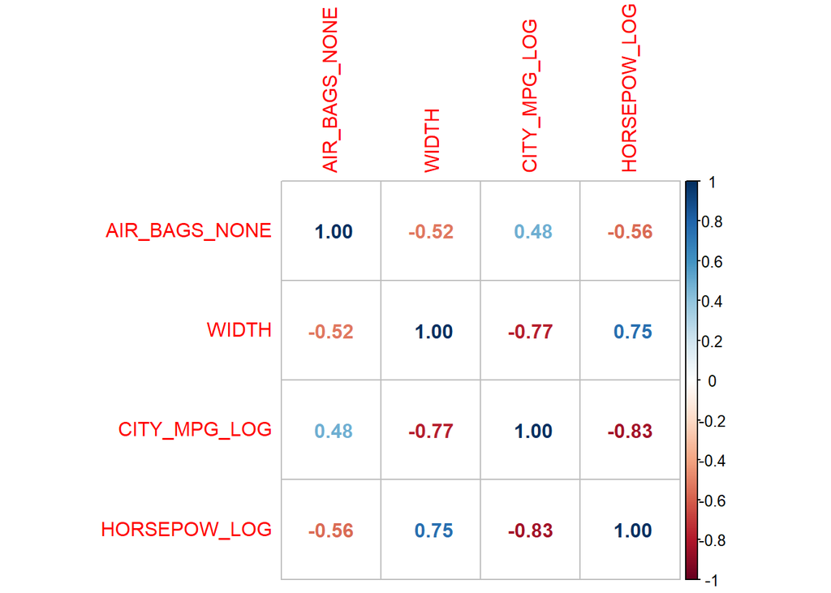

```r
corrplot(
  df.dummy |> dplyr::select(AIR_BAGS_NONE, WIDTH, CITY_MPG_LOG, HORSEPOW_LOG) |> cor(),
  method = "number"
)
```

Признак HORRSEPOW_LOG сильно коррелирует с признаками WIDTH и CITY_MPG_LOG. Посмотрим на доверительные эллипсоиды.

```r
df.scale <- as.data.frame(scale(df.dummy))
model.lm.scale <- lm(MID_PRIC_LOG ~ ., data = df.scale)
```

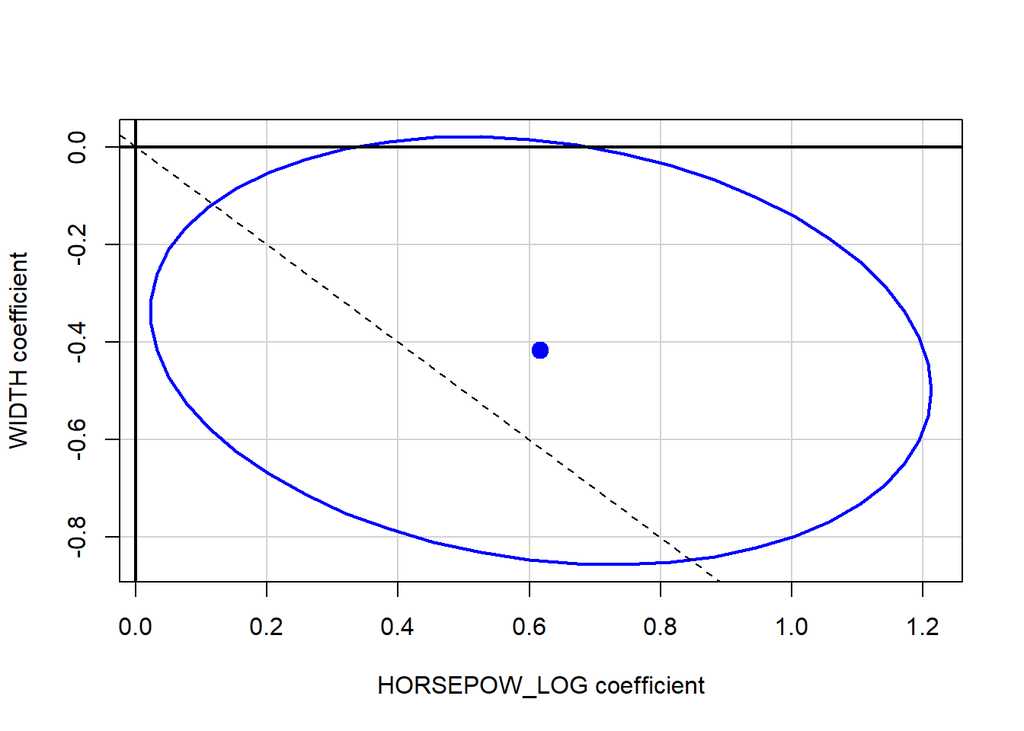

```r
confidenceEllipse(model.lm.scale, which.coef = c("HORSEPOW_LOG", "WIDTH"), levels = 0.9, col = "blue")
abline(0, -1, lty = 2)
abline(h = 0, v = 0, lwd = 2)
```

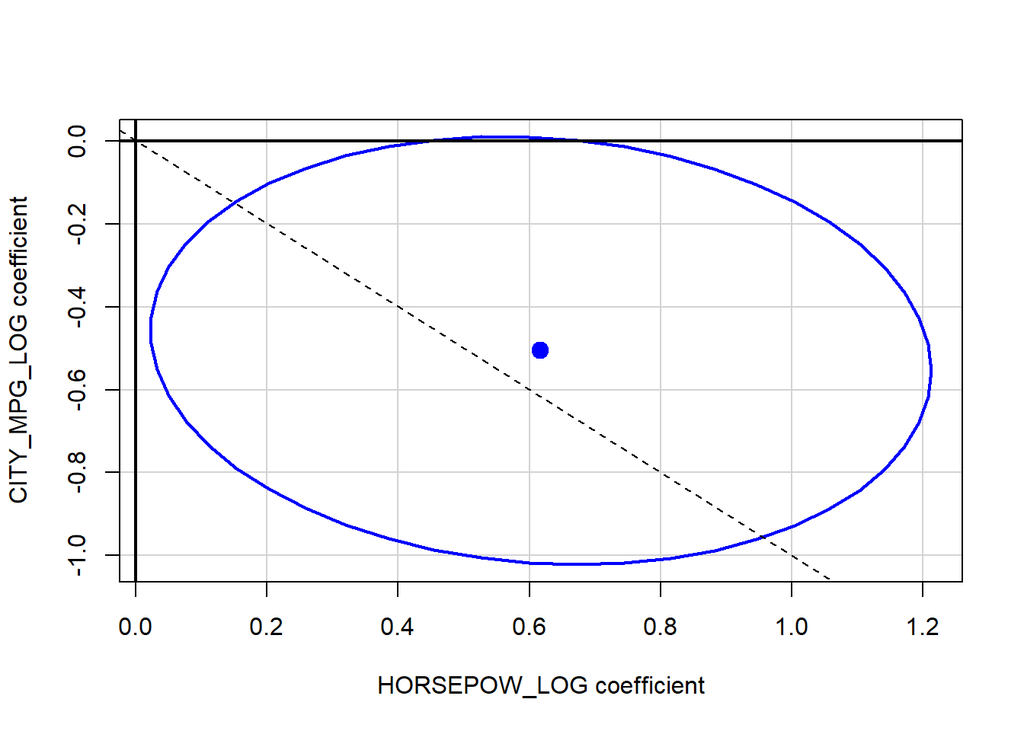

```r
confidenceEllipse(model.lm.scale, which.coef = c("HORSEPOW_LOG", "CITY_MPG_LOG"), levels = 0.9, col = "blue")
abline(0, -1, lty = 2)
abline(h = 0, v = 0, lwd = 2)
```

Ситуация не очень хорошая в обоих случаях. Проверим мультеколлинеарность.

```r
ols_vif_tol(model)
```

| Variables | Tolerance | VIF |
| --- | --- | --- |
| CITY_MPG_LOG | 0.03962710 | 25.235258 |
| HIGH_MPG_LOG | 0.05796265 | 17.252489 |
| CYLINDER | 0.14007228 | 7.139171 |
| ENGINE_LOG | 0.01247832 | 80.138967 |
| HORSEPOW_LOG | 0.02976883 | 33.592181 |
| RPM | 0.09822405 | 10.180806 |
| ENG_REV | 0.20036003 | 4.991015 |
| FUEL_CAP | 0.07407893 | 13.499115 |
| PASS_CAP | 0.22952346 | 4.356853 |
| LENGTH | 0.07686416 | 13.009964 |

[output cut: 15 more lines]

Будем убирать с регресси незначимые признаки по одному с VIF > 10, пока модель улучшается.

```r
model.reduced <- lm(MID_PRIC_LOG ~ . - ENGINE_LOG - WEIGHT - WHEELBAS - LENGTH, data = df.dummy)
summary(model.reduced)
```

```
##
## Call:
## lm(formula = MID_PRIC_LOG ~ . - ENGINE_LOG - WEIGHT - WHEELBAS -
##     LENGTH, data = df.dummy)
##
## Residuals:
##      Min       1Q   Median       3Q      Max
## -0.32810 -0.10395 -0.01827  0.10107  0.39160
##
## Coefficients:
##                     Estimate Std. Error t value Pr(>|t|)
## (Intercept)        1.905e+00  1.854e+00   1.027 0.309358
## CITY_MPG_LOG      -9.984e-01  4.712e-01  -2.119 0.039309 *
## HIGH_MPG_LOG       8.434e-01  5.267e-01   1.601 0.115889
## CYLINDER           8.232e-02  4.375e-02   1.882 0.065942 .
## HORSEPOW_LOG       6.639e-01  2.367e-01   2.805 0.007247 **
## RPM               -1.029e-06  7.582e-05  -0.014 0.989223
## ENG_REV            1.296e-04  9.417e-05   1.376 0.175166
## FUEL_CAP          -8.121e-03  2.281e-02  -0.356 0.723416
## PASS_CAP           5.636e-02  7.029e-02   0.802 0.426622
## WIDTH             -4.437e-02  2.279e-02  -1.947 0.057388 .
## U_SPACE           -1.571e-02  1.571e-02  -1.000 0.322400
## SEATROOM           2.617e-02  1.667e-02   1.570 0.123039
## LUGG_CAP           7.313e-03  1.778e-02   0.411 0.682642
## TYPE_LARGE        -1.969e-02  1.487e-01  -0.132 0.895211
## TYPE_MIDSIZE       1.471e-01  9.201e-02   1.599 0.116471
## TYPE_SMALL        -1.316e-01  1.090e-01  -1.207 0.233368
## AIR_BAGS_DRIV_PAS  9.257e-02  6.971e-02   1.328 0.190478
## AIR_BAGS_NONE     -2.483e-01  6.624e-02  -3.748 0.000478 ***
## DRIVE_FRONT        1.321e-02  1.253e-01   0.105 0.916475
## DRIVE_REAR         2.590e-01  1.445e-01   1.793 0.079299 .
## MANTRANS_YES      -3.782e-02  8.956e-02  -0.422 0.674676
## DOMESTIC_US       -8.223e-02  7.727e-02  -1.064 0.292554
## ---
## Signif. codes:  0 '***' 0.001 '**' 0.01 '*' 0.05 '.' 0.1 ' ' 1
##
## Residual standard error: 0.1872 on 48 degrees of freedom
## Multiple R-squared:  0.9013, Adjusted R-squared:  0.8581
## F-statistic: 20.86 on 21 and 48 DF,  p-value: < 2.2e-16
```

```r
AIC(model.reduced)
```

```
## [1] -16.31204
```

Итоговые VIF:

```r
ols_vif_tol(model.reduced)
```

| Variables | Tolerance | VIF |
| --- | --- | --- |
| CITY_MPG_LOG | 0.04501400 | 22.215313 |
| HIGH_MPG_LOG | 0.07155503 | 13.975257 |
| CYLINDER | 0.14643206 | 6.829106 |
| HORSEPOW_LOG | 0.06954826 | 14.378505 |
| RPM | 0.24651975 | 4.056470 |
| ENG_REV | 0.21641623 | 4.620725 |
| FUEL_CAP | 0.10286572 | 9.721411 |
| PASS_CAP | 0.25073555 | 3.988266 |
| WIDTH | 0.06928662 | 14.432801 |
| U_SPACE | 0.19438524 | 5.144423 |

[output cut: 11 more lines]

Признак HIGH_MPG_LOG не был удален, поскольку без него модель становится хуже.

Теперь посмотрим на частные корреляции с откликом и уберем те признаки, которые с ним особо не коррелируют.

```r
ols_correlations(model.reduced)
```

|  | Zero-order | Partial | Part |
| --- | --- | --- | --- |
| CITY_MPG_LOG | -0.78623058 | -0.292452231 | -0.0960995213 |
| HIGH_MPG_LOG | -0.75259741 | 0.225180754 | 0.0726243746 |
| CYLINDER | 0.71208456 | 0.262110553 | 0.0853476518 |
| HORSEPOW_LOG | 0.87102275 | 0.375258303 | 0.1272152997 |
| RPM | -0.12167942 | -0.001959833 | -0.0006158449 |
| ENG_REV | -0.56572069 | 0.194822141 | 0.0624154618 |
| FUEL_CAP | 0.80318022 | -0.051313500 | -0.0161456517 |
| PASS_CAP | 0.38142817 | 0.114962248 | 0.0363660128 |
| WIDTH | 0.63436495 | -0.270556780 | -0.0883114582 |
| U_SPACE | 0.57271234 | -0.142835336 | -0.0453485201 |

[output cut: 11 more lines]

Также тут удаляем по одному и смотрим, как ведет себя модель. Получаем следующую модель:

```r
df.reduced <-
  df.dummy |> dplyr::select(-ENGINE_LOG,-WEIGHT,-WHEELBAS,-LENGTH)
model.reduced <-
  lm(MID_PRIC_LOG ~ . - RPM - FUEL_CAP - LUGG_CAP - TYPE_LARGE - DRIVE_FRONT - MANTRANS_YES,
     data = df.reduced)
summary(model.reduced)
```

```
##
## Call:
## lm(formula = MID_PRIC_LOG ~ . - RPM - FUEL_CAP - LUGG_CAP - TYPE_LARGE -
##     DRIVE_FRONT - MANTRANS_YES, data = df.reduced)
##
## Residuals:
##      Min       1Q   Median       3Q      Max
## -0.31315 -0.11535 -0.01346  0.09941  0.37584
##
## Coefficients:
##                     Estimate Std. Error t value Pr(>|t|)
## (Intercept)        1.755e+00  1.564e+00   1.122 0.266661
## CITY_MPG_LOG      -9.829e-01  4.116e-01  -2.388 0.020453 *
## HIGH_MPG_LOG       9.059e-01  4.692e-01   1.931 0.058792 .
## CYLINDER           8.950e-02  3.553e-02   2.519 0.014770 *
## HORSEPOW_LOG       6.348e-01  1.575e-01   4.030 0.000176 ***
## ENG_REV            1.143e-04  8.217e-05   1.391 0.169980
## PASS_CAP           7.026e-02  6.256e-02   1.123 0.266390
## WIDTH             -4.728e-02  1.722e-02  -2.745 0.008195 **
## U_SPACE           -1.388e-02  1.426e-02  -0.974 0.334485
## SEATROOM           2.724e-02  1.430e-02   1.905 0.062053 .
## TYPE_MIDSIZE       1.632e-01  5.968e-02   2.735 0.008411 **
## TYPE_SMALL        -1.295e-01  9.127e-02  -1.419 0.161780
## AIR_BAGS_DRIV_PAS  9.271e-02  6.571e-02   1.411 0.164037
## AIR_BAGS_NONE     -2.472e-01  6.215e-02  -3.978 0.000209 ***
## DRIVE_REAR         2.495e-01  7.742e-02   3.222 0.002159 **
## DOMESTIC_US       -6.554e-02  6.555e-02  -1.000 0.321844
## ---
## Signif. codes:  0 '***' 0.001 '**' 0.01 '*' 0.05 '.' 0.1 ' ' 1
##
## Residual standard error: 0.1774 on 54 degrees of freedom
## Multiple R-squared:  0.9002, Adjusted R-squared:  0.8725
## F-statistic: 32.49 on 15 and 54 DF,  p-value: < 2.2e-16
```

```r
AIC(model.reduced)
```

```
## [1] -27.59169
```

Adjusted $R^2$ вырос, значимость регрессии тоже. Теперь значимыми признаками являются CITY_MPG_LOG, CYLINDER, HORSEPOW_LOG, WIDTH, TYPE_MIDSIZE, AIR_BAGS_NONE и DRIVE_REAR.

```r
ols_vif_tol(model.reduced)
```

| Variables | Tolerance | VIF |
| --- | --- | --- |
| CITY_MPG_LOG | 0.05299410 | 18.870026 |
| HIGH_MPG_LOG | 0.08096782 | 12.350586 |
| CYLINDER | 0.19934019 | 5.016550 |
| HORSEPOW_LOG | 0.14103155 | 7.090612 |
| ENG_REV | 0.25524027 | 3.917877 |
| PASS_CAP | 0.28424456 | 3.518097 |
| WIDTH | 0.10894275 | 9.179133 |
| U_SPACE | 0.21202673 | 4.716386 |
| SEATROOM | 0.41707436 | 2.397654 |
| TYPE_MIDSIZE | 0.58604821 | 1.706344 |

[output cut: 5 more lines]

```r
ols_correlations(model.reduced)
```

|  | Zero-order | Partial | Part |
| --- | --- | --- | --- |
| CITY_MPG_LOG | -0.78623058 | -0.3090917 | -0.10265453 |
| HIGH_MPG_LOG | -0.75259741 | 0.2540970 | 0.08298103 |
| CYLINDER | 0.71208456 | 0.3242465 | 0.10826368 |
| HORSEPOW_LOG | 0.87102275 | 0.4808276 | 0.17320776 |
| ENG_REV | -0.56572069 | 0.1859673 | 0.05978131 |
| PASS_CAP | 0.38142817 | 0.1510719 | 0.04827063 |
| WIDTH | 0.63436495 | -0.3499550 | -0.11799588 |
| U_SPACE | 0.57271234 | -0.1313724 | -0.04185724 |
| SEATROOM | 0.48609195 | 0.2509970 | 0.08190015 |
| TYPE_MIDSIZE | 0.50468909 | 0.3488613 | 0.11757592 |

[output cut: 5 more lines]

```r
fwd <- ols_step_forward_p(model.reduced)
fwd
```

```
##
##
##                                Stepwise Summary
## -----------------------------------------------------------------------------
## Step    Variable               AIC        SBC      SBIC      R2       Adj. R2
## -----------------------------------------------------------------------------
##  0      Base Model           103.755    108.252      NA    0.00000    0.00000
##  1      HORSEPOW_LOG           6.241     12.986      NA    0.75868    0.75513
##  2      AIR_BAGS_NONE         -5.162      3.832      NA    0.80073    0.79478
##  3      TYPE_MIDSIZE          -9.827      1.416      NA    0.81883    0.81059
##  4      DRIVE_REAR           -13.397      0.094      NA    0.83269    0.82239
##  5      WIDTH                -15.248      0.492      NA    0.84164    0.82927
##  6      SEATROOM             -22.598     -4.610      NA    0.86144    0.84825
##  7      CITY_MPG_LOG         -25.261     -5.024      NA    0.87037    0.85574
##  8      AIR_BAGS_DRIV_PAS    -27.180     -4.695      NA    0.87743    0.86136
##  9      CYLINDER             -27.697     -2.963      NA    0.88176    0.86402
##  10     HIGH_MPG_LOG         -28.708     -1.726      NA    0.88674    0.86754
##  11     ENG_REV              -29.771     -0.541      NA    0.89159    0.87103
## -----------------------------------------------------------------------------
##
## Final Model Output
## ------------------
##
##                          Model Summary
## ---------------------------------------------------------------
## R                       0.944       RMSE                 0.162
## R-Squared               0.892       MSE                  0.032
## Adj. R-Squared          0.871       Coef. Var            6.265
## Pred R-Squared          0.839       AIC                -29.771
## MAE                     0.134       SBC                 -0.541
## ---------------------------------------------------------------
##  RMSE: Root Mean Square Error
##  MSE: Mean Square Error
##  MAE: Mean Absolute Error
##  AIC: Akaike Information Criteria
##  SBC: Schwarz Bayesian Criteria
##
##                                ANOVA
## -------------------------------------------------------------------
##                Sum of
```

[output cut: 9 more lines]

```
##             model      Beta    Std. Error    Std. Beta      t        Sig      lower     upper
## ----------------------------------------------------------------------------------------------
##       (Intercept)     2.074         1.507                  1.376    0.174    -0.943     5.091
##      HORSEPOW_LOG     0.686         0.131        0.499     5.247    0.000     0.424     0.948
##     AIR_BAGS_NONE    -0.277         0.056       -0.269    -4.941    0.000    -0.389    -0.165
##      TYPE_MIDSIZE     0.161         0.055        0.151     2.915    0.005     0.050     0.271
##        DRIVE_REAR     0.272         0.070        0.201     3.870    0.000     0.131     0.413
##             WIDTH    -0.052         0.014       -0.394    -3.795    0.000    -0.080    -0.025
##          SEATROOM     0.035         0.013        0.161     2.718    0.009     0.009     0.060
##      CITY_MPG_LOG    -1.137         0.388       -0.516    -2.928    0.005    -1.914    -0.360
## AIR_BAGS_DRIV_PAS     0.096         0.065        0.076     1.482    0.144    -0.034     0.226
##          CYLINDER     0.067         0.033        0.182     2.053    0.045     0.002     0.133
##      HIGH_MPG_LOG     0.865         0.453        0.279     1.910    0.061    -0.042     1.772
##           ENG_REV     0.000         0.000        0.136     1.611    0.113     0.000     0.000
## ----------------------------------------------------------------------------------------------
```

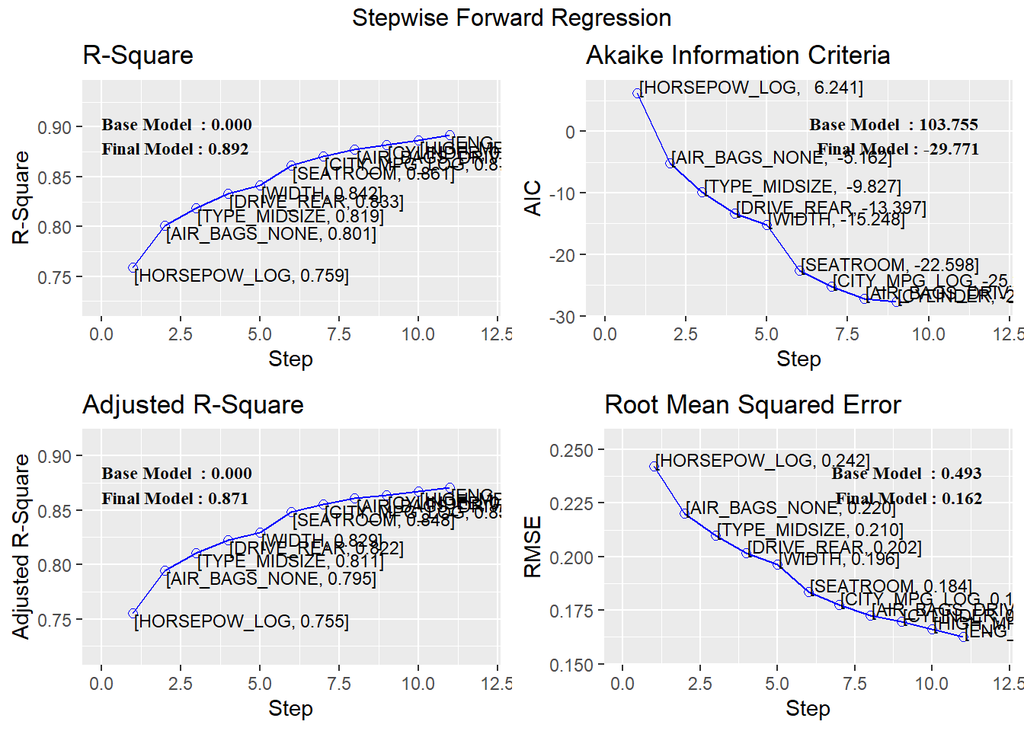

```r
plot(fwd)
```

```r
AIC(fwd$model)
```

```
## [1] -29.77126
```

```r
bwd <- ols_step_backward_p(model.reduced)
bwd
```

```
##
##
##                            Stepwise Summary
## ---------------------------------------------------------------------
## Step    Variable        AIC       SBC      SBIC      R2       Adj. R2
## ---------------------------------------------------------------------
##  0      Full Model    -27.592    10.633      NA    0.90024    0.87252
##  1      U_SPACE       -28.373     7.603      NA    0.89848    0.87264
## ---------------------------------------------------------------------
##
## Final Model Output
## ------------------
##
##                          Model Summary
## ---------------------------------------------------------------
## R                       0.948       RMSE                 0.157
## R-Squared               0.898       MSE                  0.031
## Adj. R-Squared          0.873       Coef. Var            6.225
## Pred R-Squared          0.833       AIC                -28.373
## MAE                     0.127       SBC                  7.603
## ---------------------------------------------------------------
##  RMSE: Root Mean Square Error
##  MSE: Mean Square Error
##  MAE: Mean Absolute Error
##  AIC: Akaike Information Criteria
##  SBC: Schwarz Bayesian Criteria
##
##                                ANOVA
## -------------------------------------------------------------------
##                Sum of
##               Squares        DF    Mean Square      F         Sig.
## -------------------------------------------------------------------
## Regression     15.312        14          1.094    34.771    0.0000
## Residual        1.730        55          0.031
## Total          17.042        69
## -------------------------------------------------------------------
##
##                                      Parameter Estimates
## ----------------------------------------------------------------------------------------------
##             model      Beta    Std. Error    Std. Beta      t        Sig      lower     upper
## ----------------------------------------------------------------------------------------------
##       (Intercept)     1.662         1.560                  1.065    0.291    -1.464     4.788
##      CITY_MPG_LOG    -1.013         0.410       -0.459    -2.468    0.017    -1.835    -0.190
##      HIGH_MPG_LOG     0.937         0.468        0.302     2.002    0.050    -0.001     1.875
##          CYLINDER     0.091         0.035        0.247     2.564    0.013     0.020     0.162
##      HORSEPOW_LOG     0.619         0.157        0.450     3.953    0.000     0.305     0.933
##           ENG_REV     0.000         0.000        0.128     1.512    0.136     0.000     0.000
##          PASS_CAP     0.074         0.062        0.096     1.194    0.238    -0.051     0.199
##             WIDTH    -0.052         0.016       -0.395    -3.182    0.002    -0.085    -0.019
##          SEATROOM     0.024         0.014        0.112     1.731    0.089    -0.004     0.052
##      TYPE_MIDSIZE     0.157         0.059        0.148     2.653    0.010     0.039     0.276
##        TYPE_SMALL    -0.109         0.089       -0.102    -1.232    0.223    -0.288     0.069
## AIR_BAGS_DRIV_PAS     0.104         0.065        0.082     1.599    0.116    -0.026     0.233
##     AIR_BAGS_NONE    -0.233         0.060       -0.226    -3.858    0.000    -0.354    -0.112
##        DRIVE_REAR     0.264         0.076        0.195     3.475    0.001     0.112     0.416
##       DOMESTIC_US    -0.084         0.063       -0.085    -1.334    0.188    -0.210     0.042
## ----------------------------------------------------------------------------------------------
```

[output not shown]

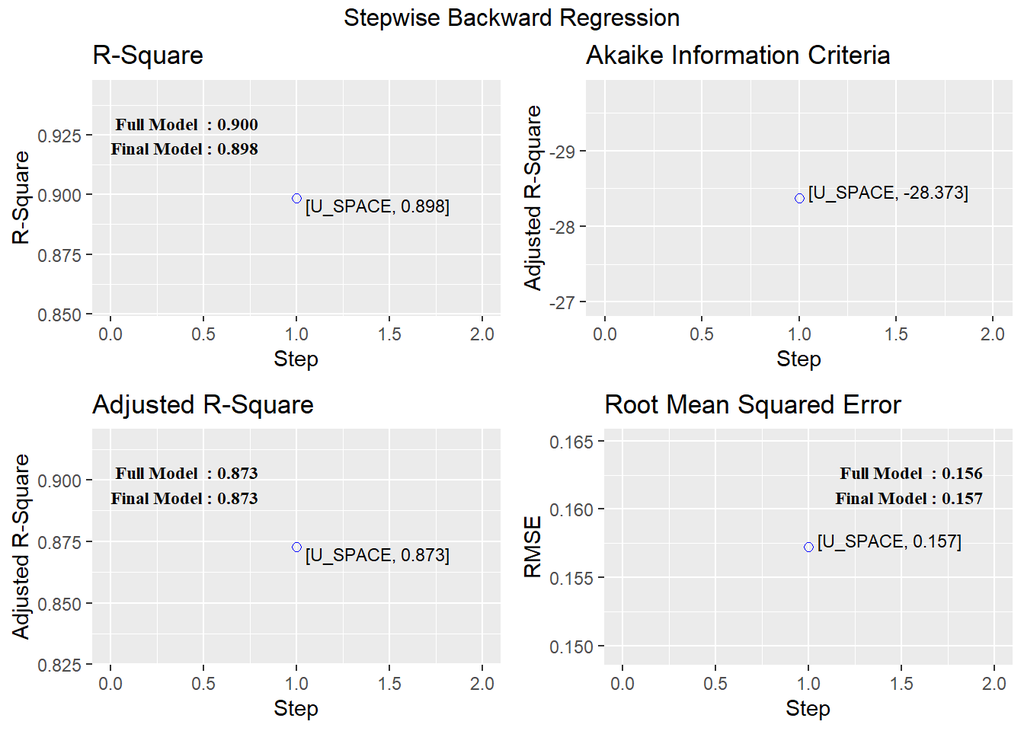

```r
plot(bwd)
```

```r
AIC(bwd$model)
```

```
## [1] -28.37303
```

Forward stepwise дает меньший AIC и более значимую регрессию, поэтому остановимся на этой модели.

```r
model.stepwise <- fwd$model
summary(model.stepwise)
```

```
##
## Call:
## lm(formula = paste(response, "~", paste(preds, collapse = " + ")),
##     data = l)
##
## Residuals:
##      Min       1Q   Median       3Q      Max
## -0.35980 -0.13430 -0.01511  0.12142  0.40327
##
## Coefficients:
##                     Estimate Std. Error t value Pr(>|t|)
## (Intercept)        2.0742158  1.5073054   1.376 0.174078
## HORSEPOW_LOG       0.6863023  0.1308045   5.247 2.28e-06 ***
## AIR_BAGS_NONE     -0.2765691  0.0559731  -4.941 6.95e-06 ***
## TYPE_MIDSIZE       0.1609021  0.0551916   2.915 0.005043 **
## DRIVE_REAR         0.2719648  0.0702672   3.870 0.000278 ***
## WIDTH             -0.0521591  0.0137433  -3.795 0.000355 ***
## SEATROOM           0.0346690  0.0127556   2.718 0.008648 **
## CITY_MPG_LOG      -1.1369343  0.3882888  -2.928 0.004867 **
## AIR_BAGS_DRIV_PAS  0.0961185  0.0648785   1.482 0.143882
## CYLINDER           0.0672341  0.0327552   2.053 0.044630 *
## HIGH_MPG_LOG       0.8651874  0.4530497   1.910 0.061122 .
## ENG_REV            0.0001313  0.0000815   1.611 0.112663
## ---
## Signif. codes:  0 '***' 0.001 '**' 0.01 '*' 0.05 '.' 0.1 ' ' 1
##
## Residual standard error: 0.1785 on 58 degrees of freedom
## Multiple R-squared:  0.8916, Adjusted R-squared:  0.871
## F-statistic: 43.36 on 11 and 58 DF,  p-value: < 2.2e-16
```

```r
ols_vif_tol(model.stepwise)
```

| Variables | Tolerance | VIF |
| --- | --- | --- |
| HORSEPOW_LOG | 0.20695026 | 4.832079 |
| AIR_BAGS_NONE | 0.63265347 | 1.580644 |
| TYPE_MIDSIZE | 0.69321380 | 1.442556 |
| DRIVE_REAR | 0.69586955 | 1.437051 |
| WIDTH | 0.17310417 | 5.776868 |
| SEATROOM | 0.53004895 | 1.886618 |
| CITY_MPG_LOG | 0.06023761 | 16.600923 |
| AIR_BAGS_DRIV_PAS | 0.71492119 | 1.398756 |
| CYLINDER | 0.23736196 | 4.212975 |
| HIGH_MPG_LOG | 0.08788213 | 11.378877 |

[output cut: 1 more lines]

```r
ols_correlations(model.stepwise)
```

|  | Zero-order | Partial | Part |
| --- | --- | --- | --- |
| HORSEPOW_LOG | 0.8710227 | 0.5673314 | 0.22684037 |
| AIR_BAGS_NONE | -0.6584080 | -0.5442799 | -0.21362487 |
| TYPE_MIDSIZE | 0.5046891 | 0.3575036 | 0.12604228 |
| DRIVE_REAR | 0.4478906 | 0.4530618 | 0.16733543 |
| WIDTH | 0.6343650 | -0.4460252 | -0.16408470 |
| SEATROOM | 0.4860919 | 0.3361202 | 0.11750834 |
| CITY_MPG_LOG | -0.7862306 | -0.3588638 | -0.12659255 |
| AIR_BAGS_DRIV_PAS | 0.4906286 | 0.1909532 | 0.06405224 |
| CYLINDER | 0.7120846 | 0.2602363 | 0.08874358 |
| HIGH_MPG_LOG | -0.7525974 | 0.2432252 | 0.08256423 |

[output cut: 1 more lines]

Остановимся на этой модели.

# 4. Проверка модели

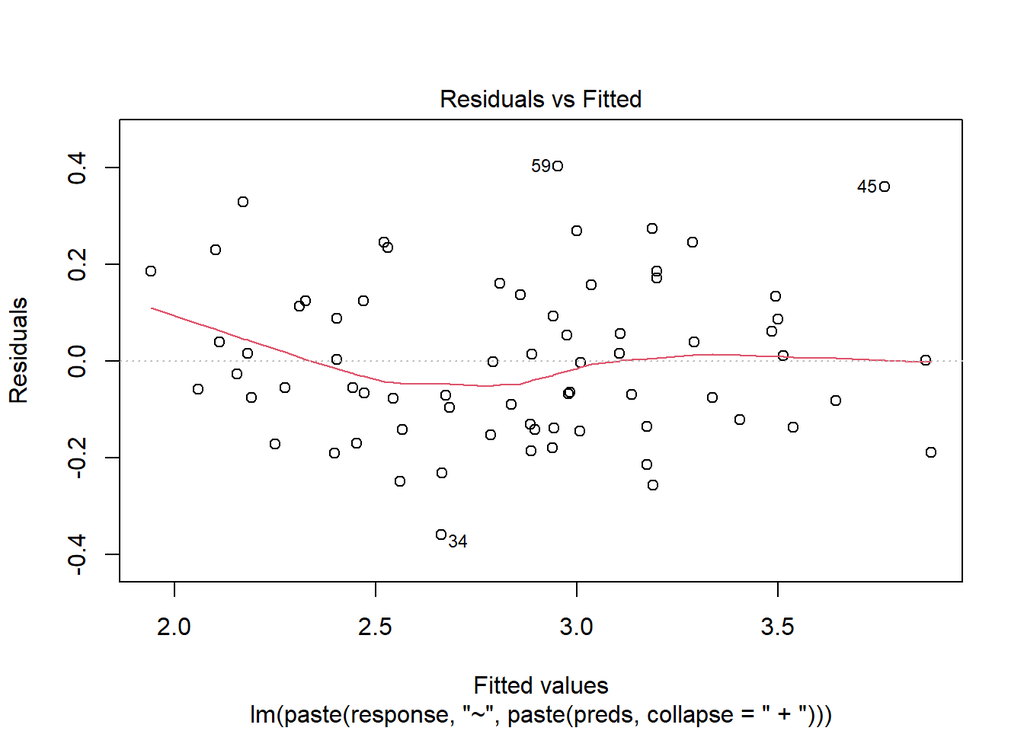

```r
plot(model.stepwise, which = 1)
```

По графику Residuals vs Predicted видно, что модель не совсем линейная, что, действительно, можно увидеть, взглянув на pairs оставшихся признаков.

```r
df.new <-
  df.dummy |> dplyr::select(
    MID_PRIC_LOG,
    CITY_MPG_LOG,
    HIGH_MPG_LOG,
    HORSEPOW_LOG,
    ENG_REV,
    WIDTH,
    SEATROOM,
    CYLINDER,
    AIR_BAGS_DRIV_PAS,
    AIR_BAGS_NONE,
    TYPE_MIDSIZE,
    DRIVE_REAR
  )

df.new[, 1:7] |>
  scatterPlotMatrix(
    regressionType = 0,
    corrPlotType = "Text",
    plotProperties = list(noCatColor = "Indigo"),
    controlWidgets = TRUE,
    height = 1000,
    width = 900
  )
```

[interactive chart not shown]

Проверим нормальность остатков.

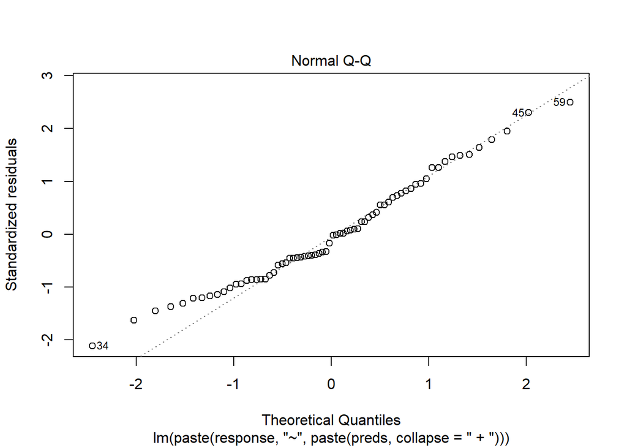

```r
plot(model.stepwise, which = 2)
```

Не очень похоже на нормальное распределение. Проверим остатки на гомоскедастичность.

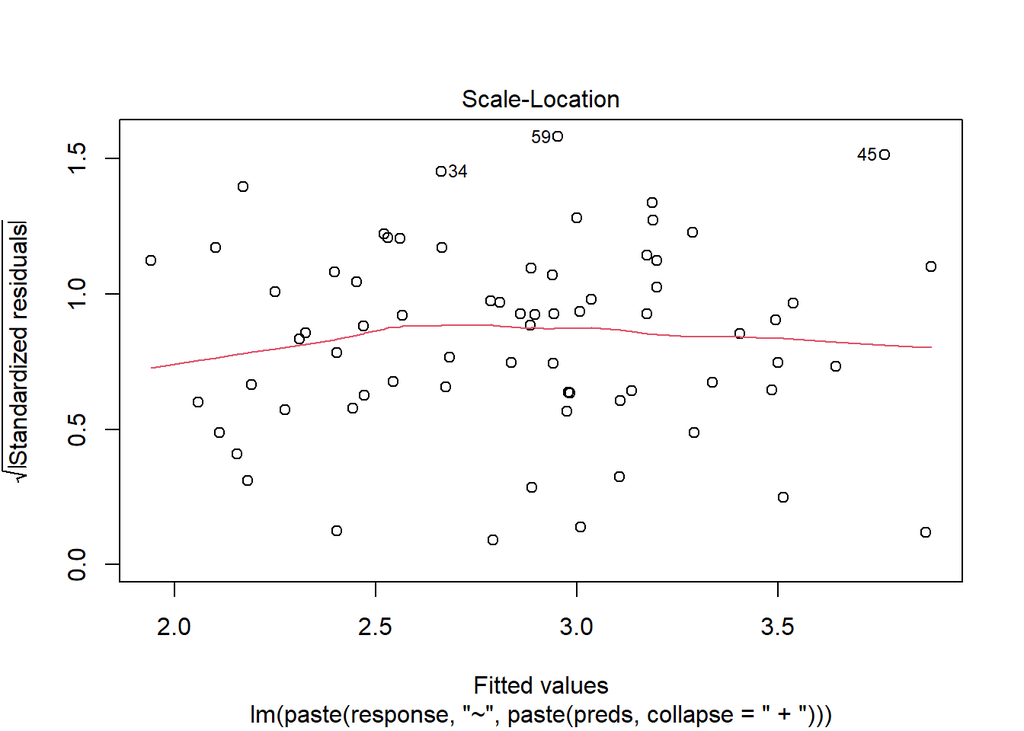

```r
plot(model.stepwise, which = 3)
```

Скорее всего, дисперсия постоянная.

# 5. Выбросы

Теперь займемся определением выбросов. Сначала посмотрим на график Deleted Residuals vs Residuals

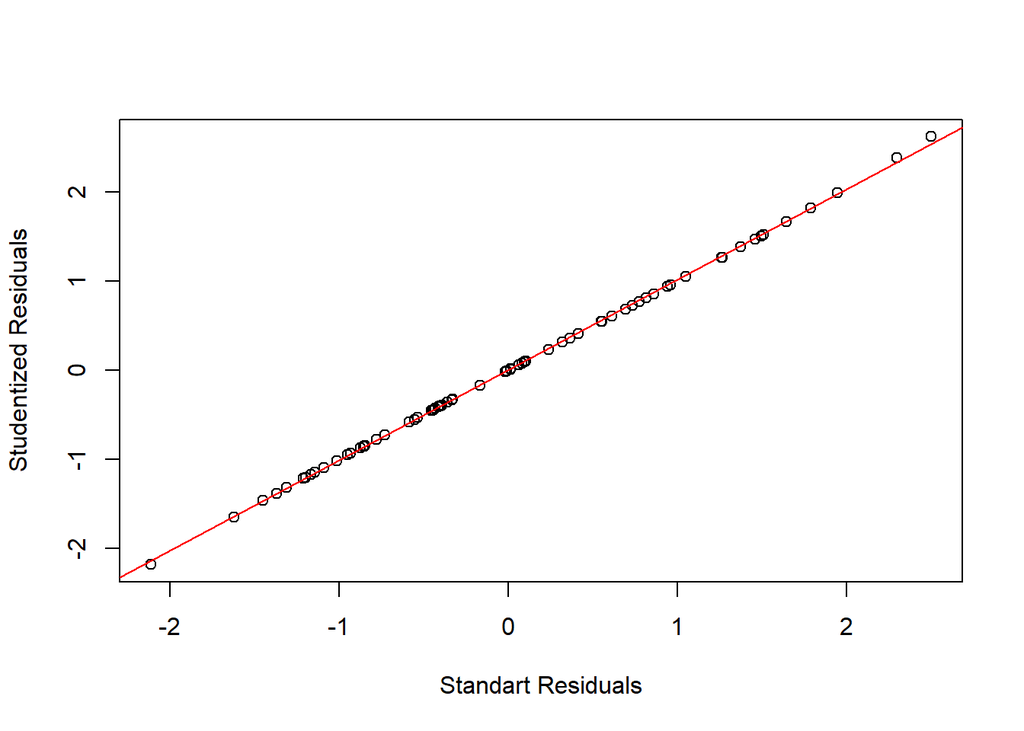

```r
deleted_resid <- studres(model.stepwise)
resid <- rstandard(model.stepwise)
plot(deleted_resid ~ resid, xlab = "Standart Residuals", ylab = "Studentized Residuals")
abline(lm(deleted_resid ~ resid), col = "red")
```

Почти все точки лежат на прямой, выбросов не обнаружено.

Теперь посмотрим на аутлаеры по Куку и Махаланобису. Чтобы было наглядней, отсортируем расстояния по убыванию.

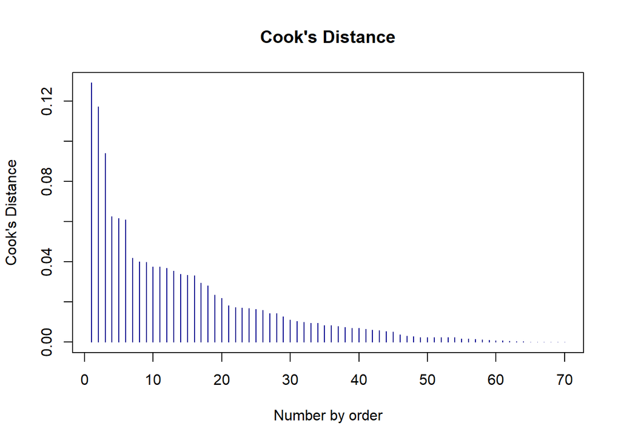

```r
cooks_distance <- cooks.distance(model.stepwise)

plot(cooks_distance[order(cooks_distance, decreasing = TRUE)],
     col = "darkblue",
     type = "h",
     main = "Cook's Distance",
     xlab = "Number by order",
     ylab = "Cook's Distance")
```

Похоже, первые 3 с наибольшим расстоянием Кука являются выбросами, поскольку имеется резкий скачок. Это признаки 45, 59 и 44.

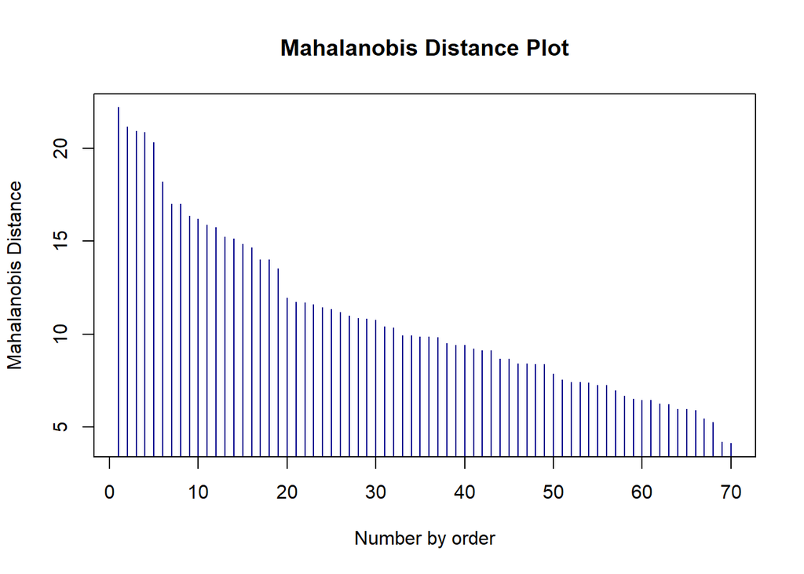

```r
regressors <-
  df.new |> dplyr::select(-MID_PRIC_LOG)

mahalanobis_distance <- mahalanobis(regressors, colMeans(regressors), cov(regressors))

plot(mahalanobis_distance[order(mahalanobis_distance, decreasing = TRUE)],
     main = "Mahalanobis Distance Plot",
     xlab = "Number by order",
     ylab = "Mahalanobis Distance",
     type = "h",
     col = "darkblue")
```

Здесь выбросы не видны.

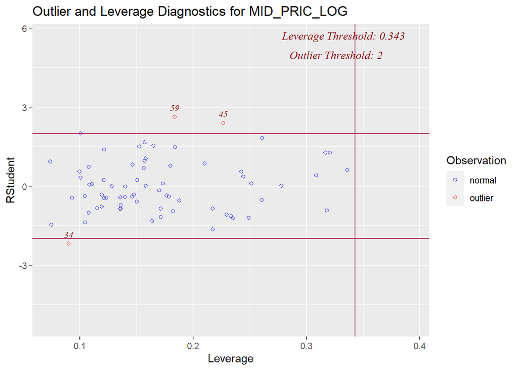

```r
ols_plot_resid_lev(model.stepwise)
```

Тут тоже выбросы не наблюдаются, поскольку 5% данных, выходящих за $2\sigma$, допустимо.

Давайте тогда удалим подозрительные наблюдения и посмотрим, улучшится ли модель.

```r
df.clear <- df.new[-c(45, 59, 44), ]
model.clear <- lm(MID_PRIC_LOG ~ ., data = df.clear)
summary(model.clear)
```

```
##
## Call:
## lm(formula = MID_PRIC_LOG ~ ., data = df.clear)
##
## Residuals:
##       Min        1Q    Median        3Q       Max
## -0.311366 -0.099944  0.000306  0.113510  0.290257
##
## Coefficients:
##                     Estimate Std. Error t value Pr(>|t|)
## (Intercept)        6.914e-01  1.344e+00   0.514 0.609071
## CITY_MPG_LOG      -7.629e-01  3.583e-01  -2.130 0.037704 *
## HIGH_MPG_LOG       6.705e-01  4.065e-01   1.650 0.104743
## HORSEPOW_LOG       6.526e-01  1.139e-01   5.731 4.36e-07 ***
## ENG_REV            8.870e-05  7.326e-05   1.211 0.231188
## WIDTH             -3.971e-02  1.256e-02  -3.161 0.002554 **
## SEATROOM           4.171e-02  1.119e-02   3.728 0.000457 ***
## CYLINDER           7.831e-02  2.862e-02   2.736 0.008357 **
## AIR_BAGS_DRIV_PAS  7.929e-02  5.860e-02   1.353 0.181546
## AIR_BAGS_NONE     -2.270e-01  5.023e-02  -4.519 3.33e-05 ***
## TYPE_MIDSIZE       1.921e-01  5.015e-02   3.830 0.000330 ***
## DRIVE_REAR         1.768e-01  6.885e-02   2.568 0.012968 *
## ---
## Signif. codes:  0 '***' 0.001 '**' 0.01 '*' 0.05 '.' 0.1 ' ' 1
##
## Residual standard error: 0.1547 on 55 degrees of freedom
## Multiple R-squared:  0.9104, Adjusted R-squared:  0.8924
## F-statistic: 50.79 on 11 and 55 DF,  p-value: < 2.2e-16
```

```r
AIC(model.clear)
```

```
## [1] -47.13805
```

Модель стала лучше, оставим ее.

# 6. Предсказание

Теперь займемся предсказанием. Добавим Kia Rio 2023.

```r
kia_rio <-
  data.frame(
    CITY_MPG_LOG = log(32),
    HIGH_MPG_LOG = log(41),
    HORSEPOW_LOG = log(120),
    ENG_REV = 2400,
    WIDTH = 67.9,
    SEATROOM = 33.5,
    CYLINDER = 4,
    AIR_BAGS_DRIV_PAS = 1,
    AIR_BAGS_NONE = 0,
    TYPE_MIDSIZE = 0,
    DRIVE_REAR = 0
  )

pred.conf <- predict(model.clear, newdata = kia_rio, interval = "confidence")
pred.predict <- predict(model.clear, newdata = kia_rio, interval = "prediction")

pred <- cbind(matrix(pred.conf, nrow = 1), matrix(pred.predict[, 2:3], nrow = 1))
colnames(pred) <- c("fit", "conf.lwr", "conf.upr", "pred.lwr", "pred.upr")
exp(pred)
```

```
##          fit conf.lwr conf.upr pred.lwr pred.upr
## [1,] 19.4637 15.86572 23.87763 13.42558 28.21747
```

Настоящая средняя цена (приблизительно) – 18.375 тыс $.